# Optimal Treatment Analysis

## Outcome Variable

**Outcome Variable:** ever_wasted

## Predictor Variables

**Intervention Variable:** hfoodsec

**Adjustment Set:**

- arm
- sex
- W_mage
- meducyrs
- feducyrs
- hhwealth_quart
- vagbrth
- W_nrooms
- W_nchldlt5
- brthmon
- W_parity
- impfloor
- impsan
- safeh20
- delta_W_mage
- delta_meducyrs
- delta_feducyrs
- delta_hhwealth_quart
- delta_vagbrth
- delta_W_nrooms
- delta_W_nchldlt5
- delta_brthmon
- delta_W_parity
- delta_impfloor
- delta_impsan
- delta_safeh20

## Stratifying Variables

The analysis was stratified on these variable(s):

- agecat
- studyid
- country

## Data Summary

| agecat | studyid | country | hfoodsec | ever_wasted | n_cell | n |
| --- | --- | --- | --- | --- | --- | --- |
| 0-24 months | ki0047075b-MAL-ED | BANGLADESH | Food Secure | 0 | 105 | 194 |
| 0-24 months | ki0047075b-MAL-ED | BANGLADESH | Food Secure | 1 | 56 | 194 |
| 0-24 months | ki0047075b-MAL-ED | BANGLADESH | Mildly Food Insecure | 0 | 3 | 194 |
| 0-24 months | ki0047075b-MAL-ED | BANGLADESH | Mildly Food Insecure | 1 | 1 | 194 |
| 0-24 months | ki0047075b-MAL-ED | BANGLADESH | Food Insecure | 0 | 19 | 194 |
| 0-24 months | ki0047075b-MAL-ED | BANGLADESH | Food Insecure | 1 | 10 | 194 |
| 0-24 months | ki0047075b-MAL-ED | BRAZIL | Food Secure | 0 | 3 | 129 |
| 0-24 months | ki0047075b-MAL-ED | BRAZIL | Food Secure | 1 | 0 | 129 |
| 0-24 months | ki0047075b-MAL-ED | BRAZIL | Mildly Food Insecure | 0 | 11 | 129 |
| 0-24 months | ki0047075b-MAL-ED | BRAZIL | Mildly Food Insecure | 1 | 0 | 129 |
| 0-24 months | ki0047075b-MAL-ED | BRAZIL | Food Insecure | 0 | 104 | 129 |
| 0-24 months | ki0047075b-MAL-ED | BRAZIL | Food Insecure | 1 | 11 | 129 |
| 0-24 months | ki0047075b-MAL-ED | INDIA | Food Secure | 0 | 98 | 212 |
| 0-24 months | ki0047075b-MAL-ED | INDIA | Food Secure | 1 | 92 | 212 |
| 0-24 months | ki0047075b-MAL-ED | INDIA | Mildly Food Insecure | 0 | 1 | 212 |
| 0-24 months | ki0047075b-MAL-ED | INDIA | Mildly Food Insecure | 1 | 4 | 212 |
| 0-24 months | ki0047075b-MAL-ED | INDIA | Food Insecure | 0 | 10 | 212 |
| 0-24 months | ki0047075b-MAL-ED | INDIA | Food Insecure | 1 | 7 | 212 |
| 0-24 months | ki0047075b-MAL-ED | NEPAL | Food Secure | 0 | 65 | 128 |
| 0-24 months | ki0047075b-MAL-ED | NEPAL | Food Secure | 1 | 29 | 128 |
| 0-24 months | ki0047075b-MAL-ED | NEPAL | Mildly Food Insecure | 0 | 11 | 128 |
| 0-24 months | ki0047075b-MAL-ED | NEPAL | Mildly Food Insecure | 1 | 4 | 128 |
| 0-24 months | ki0047075b-MAL-ED | NEPAL | Food Insecure | 0 | 10 | 128 |
| 0-24 months | ki0047075b-MAL-ED | NEPAL | Food Insecure | 1 | 9 | 128 |
| 0-24 months | ki0047075b-MAL-ED | PERU | Food Secure | 0 | 22 | 113 |
| 0-24 months | ki0047075b-MAL-ED | PERU | Food Secure | 1 | 5 | 113 |
| 0-24 months | ki0047075b-MAL-ED | PERU | Mildly Food Insecure | 0 | 29 | 113 |
| 0-24 months | ki0047075b-MAL-ED | PERU | Mildly Food Insecure | 1 | 0 | 113 |
| 0-24 months | ki0047075b-MAL-ED | PERU | Food Insecure | 0 | 49 | 113 |
| 0-24 months | ki0047075b-MAL-ED | PERU | Food Insecure | 1 | 8 | 113 |

[output cut: 168 more lines]

The following strata were considered:

- agecat: 0-24 months, studyid: ki0047075b-MAL-ED, country: BANGLADESH
- agecat: 0-24 months, studyid: ki0047075b-MAL-ED, country: BRAZIL
- agecat: 0-24 months, studyid: ki0047075b-MAL-ED, country: INDIA
- agecat: 0-24 months, studyid: ki0047075b-MAL-ED, country: NEPAL
- agecat: 0-24 months, studyid: ki0047075b-MAL-ED, country: PERU
- agecat: 0-24 months, studyid: ki0047075b-MAL-ED, country: SOUTH AFRICA
- agecat: 0-24 months, studyid: ki1017093-NIH-Birth, country: BANGLADESH
- agecat: 0-24 months, studyid: ki1017093c-NIH-Crypto, country: BANGLADESH
- agecat: 0-24 months, studyid: ki1113344-GMS-Nepal, country: NEPAL
- agecat: 0-24 months, studyid: kiGH5241-JiVitA-3, country: BANGLADESH
- agecat: 0-24 months, studyid: kiGH5241-JiVitA-4, country: BANGLADESH
- agecat: 0-6 months, studyid: ki0047075b-MAL-ED, country: BANGLADESH
- agecat: 0-6 months, studyid: ki0047075b-MAL-ED, country: BRAZIL
- agecat: 0-6 months, studyid: ki0047075b-MAL-ED, country: INDIA
- agecat: 0-6 months, studyid: ki0047075b-MAL-ED, country: NEPAL
- agecat: 0-6 months, studyid: ki0047075b-MAL-ED, country: PERU
- agecat: 0-6 months, studyid: ki0047075b-MAL-ED, country: SOUTH AFRICA
- agecat: 0-6 months, studyid: ki1017093-NIH-Birth, country: BANGLADESH
- agecat: 0-6 months, studyid: ki1017093c-NIH-Crypto, country: BANGLADESH
- agecat: 0-6 months, studyid: ki1113344-GMS-Nepal, country: NEPAL
- agecat: 0-6 months, studyid: kiGH5241-JiVitA-3, country: BANGLADESH
- agecat: 0-6 months, studyid: kiGH5241-JiVitA-4, country: BANGLADESH
- agecat: 6-24 months, studyid: ki0047075b-MAL-ED, country: BANGLADESH
- agecat: 6-24 months, studyid: ki0047075b-MAL-ED, country: BRAZIL
- agecat: 6-24 months, studyid: ki0047075b-MAL-ED, country: INDIA
- agecat: 6-24 months, studyid: ki0047075b-MAL-ED, country: NEPAL
- agecat: 6-24 months, studyid: ki0047075b-MAL-ED, country: PERU
- agecat: 6-24 months, studyid: ki0047075b-MAL-ED, country: SOUTH AFRICA
- agecat: 6-24 months, studyid: ki1017093-NIH-Birth, country: BANGLADESH
- agecat: 6-24 months, studyid: ki1017093c-NIH-Crypto, country: BANGLADESH
- agecat: 6-24 months, studyid: ki1113344-GMS-Nepal, country: NEPAL
- agecat: 6-24 months, studyid: kiGH5241-JiVitA-3, country: BANGLADESH
- agecat: 6-24 months, studyid: kiGH5241-JiVitA-4, country: BANGLADESH

### Dropped Strata

Some strata were dropped due to rare outcomes:

- agecat: 0-24 months, studyid: ki0047075b-MAL-ED, country: BANGLADESH
- agecat: 0-24 months, studyid: ki0047075b-MAL-ED, country: BRAZIL
- agecat: 0-24 months, studyid: ki0047075b-MAL-ED, country: INDIA
- agecat: 0-24 months, studyid: ki0047075b-MAL-ED, country: NEPAL
- agecat: 0-24 months, studyid: ki0047075b-MAL-ED, country: PERU
- agecat: 0-24 months, studyid: ki0047075b-MAL-ED, country: SOUTH AFRICA
- agecat: 0-6 months, studyid: ki0047075b-MAL-ED, country: BANGLADESH
- agecat: 0-6 months, studyid: ki0047075b-MAL-ED, country: BRAZIL
- agecat: 0-6 months, studyid: ki0047075b-MAL-ED, country: INDIA
- agecat: 0-6 months, studyid: ki0047075b-MAL-ED, country: NEPAL
- agecat: 0-6 months, studyid: ki0047075b-MAL-ED, country: PERU
- agecat: 0-6 months, studyid: ki0047075b-MAL-ED, country: SOUTH AFRICA
- agecat: 6-24 months, studyid: ki0047075b-MAL-ED, country: BANGLADESH
- agecat: 6-24 months, studyid: ki0047075b-MAL-ED, country: BRAZIL
- agecat: 6-24 months, studyid: ki0047075b-MAL-ED, country: INDIA
- agecat: 6-24 months, studyid: ki0047075b-MAL-ED, country: NEPAL
- agecat: 6-24 months, studyid: ki0047075b-MAL-ED, country: PERU
- agecat: 6-24 months, studyid: ki0047075b-MAL-ED, country: SOUTH AFRICA

## Methods Detail

We’re interested in the causal parameters $E[Y_a]$ for all values of $a \in \mathcal{A}$. These parameters represent the mean outcome if, possibly contrary to fact, we intervened to set all units to have $A=a$. Under the randomization and positivity assumptions, these are identified by the statistical parameters $\psi_a=E_W[E_{Y|A,W}(Y|A=a,W)]$. In addition, we’re interested in the mean of $Y$, $E[Y]$ under no intervention (the observed mean). We will estimate these parameters by using SuperLearner to fit the relevant likelihood factors – $E_{Y|A,W}(Y|A=a,W)$ and $p(A=a|W)$, and then updating our likelihood fit using a joint TMLE.

For unadjusted analyses ($W=\{\}$), initial likelihoods were estimated using Lrnr_glm to estimate the simple $E(Y|A)$ and Lrnr_mean to estimate $p(A)$. For adjusted analyses, a small library containing Lrnr_glmnet, Lrnr_xgboost, and Lrnr_mean was used.

Having estimated these parameters, we will then use the delta method to estimate relative risks and attributable risks relative to a prespecified baseline level of $A$.

# Results Detail

## Results Plots

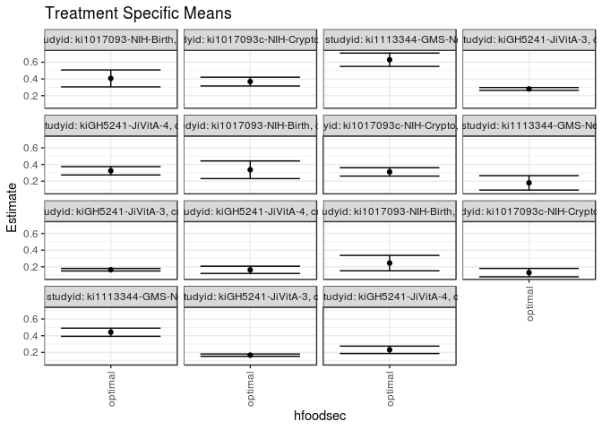

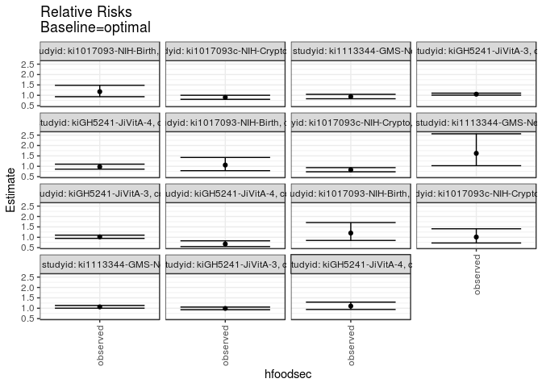

## Results Table

### Parameter: TSM

| agecat | studyid | country | intervention_level | baseline_level | estimate | ci_lower | ci_upper |
| --- | --- | --- | --- | --- | --- | --- | --- |
| 0-24 months | ki1017093-NIH-Birth | BANGLADESH | optimal | NA | 0.4063533 | 0.3050665 | 0.5076401 |
| 0-24 months | ki1017093c-NIH-Crypto | BANGLADESH | optimal | NA | 0.3683749 | 0.3156107 | 0.4211391 |
| 0-24 months | ki1113344-GMS-Nepal | NEPAL | optimal | NA | 0.6303350 | 0.5504503 | 0.7102197 |
| 0-24 months | kiGH5241-JiVitA-3 | BANGLADESH | optimal | NA | 0.2801571 | 0.2631859 | 0.2971283 |
| 0-24 months | kiGH5241-JiVitA-4 | BANGLADESH | optimal | NA | 0.3247309 | 0.2747023 | 0.3747595 |
| 0-6 months | ki1017093-NIH-Birth | BANGLADESH | optimal | NA | 0.3369298 | 0.2310725 | 0.4427871 |
| 0-6 months | ki1017093c-NIH-Crypto | BANGLADESH | optimal | NA | 0.3116279 | 0.2612780 | 0.3619779 |
| 0-6 months | ki1113344-GMS-Nepal | NEPAL | optimal | NA | 0.1802914 | 0.0939240 | 0.2666588 |
| 0-6 months | kiGH5241-JiVitA-3 | BANGLADESH | optimal | NA | 0.1649157 | 0.1496478 | 0.1801835 |
| 0-6 months | kiGH5241-JiVitA-4 | BANGLADESH | optimal | NA | 0.1637448 | 0.1202408 | 0.2072487 |
| 6-24 months | ki1017093-NIH-Birth | BANGLADESH | optimal | NA | 0.2443913 | 0.1517872 | 0.3369954 |
| 6-24 months | ki1017093c-NIH-Crypto | BANGLADESH | optimal | NA | 0.1301181 | 0.0798767 | 0.1803595 |
| 6-24 months | ki1113344-GMS-Nepal | NEPAL | optimal | NA | 0.4417568 | 0.3928822 | 0.4906314 |
| 6-24 months | kiGH5241-JiVitA-3 | BANGLADESH | optimal | NA | 0.1666361 | 0.1528785 | 0.1803938 |
| 6-24 months | kiGH5241-JiVitA-4 | BANGLADESH | optimal | NA | 0.2308182 | 0.1865496 | 0.2750868 |

### Parameter: E(Y)

| agecat | studyid | country | intervention_level | baseline_level | estimate | ci_lower | ci_upper |
| --- | --- | --- | --- | --- | --- | --- | --- |
| 0-24 months | ki1017093-NIH-Birth | BANGLADESH | observed | NA | 0.4775641 | 0.4383415 | 0.5167867 |
| 0-24 months | ki1017093c-NIH-Crypto | BANGLADESH | observed | NA | 0.3311346 | 0.2976093 | 0.3646598 |
| 0-24 months | ki1113344-GMS-Nepal | NEPAL | observed | NA | 0.5890411 | 0.5491031 | 0.6289790 |
| 0-24 months | kiGH5241-JiVitA-3 | BANGLADESH | observed | NA | 0.2952669 | 0.2842955 | 0.3062383 |
| 0-24 months | kiGH5241-JiVitA-4 | BANGLADESH | observed | NA | 0.3164200 | 0.2881624 | 0.3446776 |
| 0-6 months | ki1017093-NIH-Birth | BANGLADESH | observed | NA | 0.3569132 | 0.3192325 | 0.3945938 |
| 0-6 months | ki1017093c-NIH-Crypto | BANGLADESH | observed | NA | 0.2585752 | 0.2273844 | 0.2897660 |
| 0-6 months | ki1113344-GMS-Nepal | NEPAL | observed | NA | 0.2928082 | 0.2558702 | 0.3297463 |
| 0-6 months | kiGH5241-JiVitA-3 | BANGLADESH | observed | NA | 0.1683620 | 0.1594164 | 0.1773076 |
| 0-6 months | kiGH5241-JiVitA-4 | BANGLADESH | observed | NA | 0.1107739 | 0.0906511 | 0.1308967 |
| 6-24 months | ki1017093-NIH-Birth | BANGLADESH | observed | NA | 0.2939002 | 0.2554778 | 0.3323226 |
| 6-24 months | ki1017093c-NIH-Crypto | BANGLADESH | observed | NA | 0.1315068 | 0.1069744 | 0.1560393 |
| 6-24 months | ki1113344-GMS-Nepal | NEPAL | observed | NA | 0.4712042 | 0.4302971 | 0.5121113 |
| 6-24 months | kiGH5241-JiVitA-3 | BANGLADESH | observed | NA | 0.1651419 | 0.1559762 | 0.1743076 |
| 6-24 months | kiGH5241-JiVitA-4 | BANGLADESH | observed | NA | 0.2549435 | 0.2289436 | 0.2809434 |

### Parameter: RR

| agecat | studyid | country | intervention_level | baseline_level | estimate | ci_lower | ci_upper |
| --- | --- | --- | --- | --- | --- | --- | --- |
| 0-24 months | ki1017093-NIH-Birth | BANGLADESH | observed | optimal | 1.1752436 | 0.9329757 | 1.4804218 |
| 0-24 months | ki1017093c-NIH-Crypto | BANGLADESH | observed | optimal | 0.8989064 | 0.8066788 | 1.0016784 |
| 0-24 months | ki1113344-GMS-Nepal | NEPAL | observed | optimal | 0.9344890 | 0.8342882 | 1.0467242 |
| 0-24 months | kiGH5241-JiVitA-3 | BANGLADESH | observed | optimal | 1.0539332 | 1.0061811 | 1.1039516 |
| 0-24 months | kiGH5241-JiVitA-4 | BANGLADESH | observed | optimal | 0.9744067 | 0.8608353 | 1.1029619 |
| 0-6 months | ki1017093-NIH-Birth | BANGLADESH | observed | optimal | 1.0593102 | 0.7876193 | 1.4247213 |
| 0-6 months | ki1017093c-NIH-Crypto | BANGLADESH | observed | optimal | 0.8297562 | 0.7355097 | 0.9360792 |
| 0-6 months | ki1113344-GMS-Nepal | NEPAL | observed | optimal | 1.6240833 | 1.0287080 | 2.5640382 |
| 0-6 months | kiGH5241-JiVitA-3 | BANGLADESH | observed | optimal | 1.0208973 | 0.9463375 | 1.1013315 |
| 0-6 months | kiGH5241-JiVitA-4 | BANGLADESH | observed | optimal | 0.6765034 | 0.5518065 | 0.8293792 |
| 6-24 months | ki1017093-NIH-Birth | BANGLADESH | observed | optimal | 1.2025805 | 0.8470218 | 1.7073939 |
| 6-24 months | ki1017093c-NIH-Crypto | BANGLADESH | observed | optimal | 1.0106727 | 0.7250770 | 1.4087597 |
| 6-24 months | ki1113344-GMS-Nepal | NEPAL | observed | optimal | 1.0666597 | 1.0031672 | 1.1341707 |
| 6-24 months | kiGH5241-JiVitA-3 | BANGLADESH | observed | optimal | 0.9910331 | 0.9299422 | 1.0561374 |
| 6-24 months | kiGH5241-JiVitA-4 | BANGLADESH | observed | optimal | 1.1045209 | 0.9421607 | 1.2948603 |

### Parameter: PAR

| agecat | studyid | country | intervention_level | baseline_level | estimate | ci_lower | ci_upper |
| --- | --- | --- | --- | --- | --- | --- | --- |
| 0-24 months | ki1017093-NIH-Birth | BANGLADESH | optimal | NA | 0.0712108 | -0.0224561 | 0.1648777 |
| 0-24 months | ki1017093c-NIH-Crypto | BANGLADESH | optimal | NA | -0.0372403 | -0.0770464 | 0.0025658 |
| 0-24 months | ki1113344-GMS-Nepal | NEPAL | optimal | NA | -0.0412939 | -0.1125868 | 0.0299990 |
| 0-24 months | kiGH5241-JiVitA-3 | BANGLADESH | optimal | NA | 0.0151098 | 0.0021303 | 0.0280893 |
| 0-24 months | kiGH5241-JiVitA-4 | BANGLADESH | optimal | NA | -0.0083109 | -0.0485737 | 0.0319519 |
| 0-6 months | ki1017093-NIH-Birth | BANGLADESH | optimal | NA | 0.0199834 | -0.0798998 | 0.1198665 |
| 0-6 months | ki1017093c-NIH-Crypto | BANGLADESH | optimal | NA | -0.0530527 | -0.0905139 | -0.0155916 |
| 0-6 months | ki1113344-GMS-Nepal | NEPAL | optimal | NA | 0.1125168 | 0.0295892 | 0.1954445 |
| 0-6 months | kiGH5241-JiVitA-3 | BANGLADESH | optimal | NA | 0.0034463 | -0.0090620 | 0.0159546 |
| 0-6 months | kiGH5241-JiVitA-4 | BANGLADESH | optimal | NA | -0.0529709 | -0.0871988 | -0.0187430 |
| 6-24 months | ki1017093-NIH-Birth | BANGLADESH | optimal | NA | 0.0495089 | -0.0361375 | 0.1351553 |
| 6-24 months | ki1017093c-NIH-Crypto | BANGLADESH | optimal | NA | 0.0013887 | -0.0418151 | 0.0445925 |
| 6-24 months | ki1113344-GMS-Nepal | NEPAL | optimal | NA | 0.0294474 | 0.0024415 | 0.0564532 |
| 6-24 months | kiGH5241-JiVitA-3 | BANGLADESH | optimal | NA | -0.0014942 | -0.0120932 | 0.0091048 |
| 6-24 months | kiGH5241-JiVitA-4 | BANGLADESH | optimal | NA | 0.0241253 | -0.0125714 | 0.0608220 |

### Parameter: PAF

| agecat | studyid | country | intervention_level | baseline_level | estimate | ci_lower | ci_upper |
| --- | --- | --- | --- | --- | --- | --- | --- |
| 0-24 months | ki1017093-NIH-Birth | BANGLADESH | optimal | NA | 0.1491126 | -0.0718393 | 0.3245168 |
| 0-24 months | ki1017093c-NIH-Crypto | BANGLADESH | optimal | NA | -0.1124628 | -0.2396507 | 0.0016756 |
| 0-24 months | ki1113344-GMS-Nepal | NEPAL | optimal | NA | -0.0701036 | -0.1986266 | 0.0446385 |
| 0-24 months | kiGH5241-JiVitA-3 | BANGLADESH | optimal | NA | 0.0511733 | 0.0061431 | 0.0941632 |
| 0-24 months | kiGH5241-JiVitA-4 | BANGLADESH | optimal | NA | -0.0262655 | -0.1616624 | 0.0933504 |
| 0-6 months | ki1017093-NIH-Birth | BANGLADESH | optimal | NA | 0.0559894 | -0.2696489 | 0.2981084 |
| 0-6 months | ki1017093c-NIH-Crypto | BANGLADESH | optimal | NA | -0.2051733 | -0.3596014 | -0.0682857 |
| 0-6 months | ki1113344-GMS-Nepal | NEPAL | optimal | NA | 0.3842680 | 0.0279069 | 0.6099902 |
| 0-6 months | kiGH5241-JiVitA-3 | BANGLADESH | optimal | NA | 0.0204695 | -0.0567055 | 0.0920082 |
| 0-6 months | kiGH5241-JiVitA-4 | BANGLADESH | optimal | NA | -0.4781892 | -0.8122294 | -0.2057212 |
| 6-24 months | ki1017093-NIH-Birth | BANGLADESH | optimal | NA | 0.1684548 | -0.1806072 | 0.4143121 |
| 6-24 months | ki1017093c-NIH-Crypto | BANGLADESH | optimal | NA | 0.0105600 | -0.3791638 | 0.2901557 |
| 6-24 months | ki1113344-GMS-Nepal | NEPAL | optimal | NA | 0.0624939 | 0.0031572 | 0.1182985 |
| 6-24 months | kiGH5241-JiVitA-3 | BANGLADESH | optimal | NA | -0.0090480 | -0.0753357 | 0.0531535 |
| 6-24 months | kiGH5241-JiVitA-4 | BANGLADESH | optimal | NA | 0.0946301 | -0.0613901 | 0.2277159 |